# EasyVisa Project

## Context:

Business communities in the United States are facing high demand for human resources, but one of the constant challenges is identifying and attracting the right talent, which is perhaps the most important element in remaining competitive. Companies in the United States look for hard-working, talented, and qualified individuals both locally as well as abroad.

The Immigration and Nationality Act (INA) of the US permits foreign workers to come to the United States to work on either a temporary or permanent basis. The act also protects US workers against adverse impacts on their wages or working conditions by ensuring US employers' compliance with statutory requirements when they hire foreign workers to fill workforce shortages. The immigration programs are administered by the Office of Foreign Labor Certification (OFLC).

OFLC processes job certification applications for employers seeking to bring foreign workers into the United States and grants certifications in those cases where employers can demonstrate that there are not sufficient US workers available to perform the work at wages that meet or exceed the wage paid for the occupation in the area of intended employment.

## Objective:

In FY 2016, the OFLC processed 775,979 employer applications for 1,699,957 positions for temporary and permanent labor certifications. This was a nine percent increase in the overall number of processed applications from the previous year. The process of reviewing every case is becoming a tedious task as the number of applicants is increasing every year.

The increasing number of applicants every year calls for a Machine Learning based solution that can help in shortlisting the candidates having higher chances of VISA approval. OFLC has hired your firm EasyVisa for data-driven solutions. You as a data scientist have to analyze the data provided and, with the help of a classification model:

- Facilitate the process of visa approvals.
- Recommend a suitable profile for the applicants for whom the visa should be certified or denied based on the drivers that significantly influence the case status.

## Data Description

The data contains the different attributes of the employee and the employer. The detailed data dictionary is given below.

- case_id: ID of each visa application
- continent: Information of continent the employee
- education_of_employee: Information of education of the employee
- has_job_experience: Does the employee has any job experience? Y= Yes; N = No
- requires_job_training: Does the employee require any job training? Y = Yes; N = No
- no_of_employees: Number of employees in the employer's company
- yr_of_estab: Year in which the employer's company was established
- region_of_employment: Information of foreign worker's intended region of employment in the US.
- prevailing_wage: Average wage paid to similarly employed workers in a specific occupation in the area of intended employment. The purpose of the prevailing wage is to ensure that the foreign worker is not underpaid compared to other workers offering the same or similar service in the same area of employment.
- unit_of_wage: Unit of prevailing wage. Values include Hourly, Weekly, Monthly, and Yearly.
- full_time_position: Is the position of work full-time? Y = Full Time Position; N = Part Time Position
- case_status: Flag indicating if the Visa was certified or denied

## Model evaluation criterion

### Model can make wrong predictions as:

1. Model predicts that the visa application will get certified but in reality, the visa application should get denied.
2. Model predicts that the visa application will not get certified but in reality, the visa application should get certified.

### Which case is more important?

Both the cases are important as:

- If a visa is certified when it had to be denied a wrong employee will get the job position while US citizens will miss the opportunity to work on that position.
- If a visa is denied when it had to be certified the U.S. will lose a suitable human resource that can contribute to the economy.

### How to reduce the losses?

- F1 Score can be used a the metric for evaluation of the model, greater the F1 score higher are the chances of minimizing False Negatives and False Positives.
- Balanced class weights will be use so that model focuses equally on both classes.

### F1 Definition

The F1 score can be interpreted as a harmonic mean of the precision and recall, where an F1 score reaches its best value at 1 and worst score at 0. The relative contribution of precision and recall to the F1 score are equal.

## Historical Overview

People choose to leave their native countries for many reasons. Lack of opportunities, political situation, and wanting a better life are all mentioned as reasons for wanting to immigrate.

Looking over time the people with advanced knowledge and/or advanced degrees are usually the ones that immigrate first and have the easiest time immigrating and getting a job. There have been many examples of this over the years.

1. Operation Paperclip
   - Operation Paperclip was a secret United States intelligence program in which more than 1,600 Nazi German scientists, engineers, and technicians were taken from former Nazi Germany to the U.S. for government employment after the end of World War II in Europe, between 1945 and 1959.
2. East Germany in November 1989
   - After East Germany opened its boarders in November 1989, some of the first people to leave were skilled professionals.
3. Russia today
   - There are news reports stating as many as 100,000 IT professionals in Russia have left the country since the start of the war in Ukraine. That is a rather large hit.
   - The Biden administration is actively working on getting technical professionals to leave Russia and move to other countries.

For the purposes of this assignment, we are going to operate under the assumption that history can and does repeat itself and the smartest and most capable are the ones most likely to immigrate.

Sources:

- https://www.nytimes.com/2022/04/13/technology/russia-tech-workers.html
- https://sciencebusiness.net/news/us-plans-campaign-attract-russian-scientists-engineers-america
- https://en.wikipedia.org/wiki/Operation_Paperclip#:~:text=Operation%20Paperclip%20was%20a%20secret,Europe%2C%20between%201945%20and%201959.

## Notes to reviewer

From time to time, you will find the %%time command included in some cells. It is there because I was interested in knowing the execution time of some cells, especially the cells than run complex commands. The command is not critical to the final outcome, but interesting to know.

I did both stacked and side-by-side barplots as I think the side-by-side plots are easier to read.

I also added a table with the percentages to the stacked and side-by-side barplots as I think the percentages are easier to understand and process rather than the raw numbers.

For all the models, I followed this pattern:

1. Check Base Model Performance on Training Set
2. Check Base Model Performance on Test Set
3. Perform Hyperparameter Tuning
4. Check Tuned Model Performance on Training Set
5. Check Tuned Model Performance on Test Set
6. Model Performance Comparison and Conclusions
7. Save DataFrame to Disk for future reload

I am not the world's greatest speller so there will be spelling mistakes. Jupyter really needs a spell checker.

## Importing necessary libraries and data

```python
# this will help in making the Python code more structured automatically (good coding practice)
%load_ext nb_black

import warnings

warnings.filterwarnings("ignore")

from statsmodels.tools.sm_exceptions import ConvergenceWarning

warnings.simplefilter("ignore", ConvergenceWarning)

# Libraries to help with reading and manipulating data
import numpy as np
import pandas as pd
from IPython.display import display_html

# Library to split data
from sklearn.model_selection import train_test_split

# libaries to help with data visualization
import matplotlib.pyplot as plt
import seaborn as sns

# Removes the limit for the number of displayed columns
pd.set_option("display.max_columns", None)
# Sets the limit for the number of displayed rows
pd.set_option("display.max_rows", 100)


# Libraries different ensemble classifiers
from sklearn.ensemble import (
    BaggingClassifier,
    RandomForestClassifier,
    AdaBoostClassifier,
    GradientBoostingClassifier,
    StackingClassifier,
    StackingRegressor,
)

from xgboost import XGBClassifier
from sklearn.tree import DecisionTreeClassifier

# Libraries to get different metric scores
from sklearn import metrics
from sklearn.metrics import (
    confusion_matrix,
    accuracy_score,
    precision_score,
    recall_score,
    f1_score,
    make_scorer,
)

# To tune different models
from sklearn.model_selection import GridSearchCV

# To build model for prediction
import statsmodels.stats.api as sms
from statsmodels.stats.outliers_influence import variance_inflation_factor
import statsmodels.api as sm
from statsmodels.tools.tools import add_constant
from sklearn.tree import DecisionTreeClassifier
from sklearn import tree
```

```
The nb_black extension is already loaded. To reload it, use:
  %reload_ext nb_black
```

## Function Definitions

I am old fashioned and was originally trained in procedural code. I like defining functions at the top of the notebook. I also find it is better to have everything defined upfront so you can define and load everything all at once. The flow of the code is also not interrupted with a function defintion.

```python
def histogram_boxplot(data, feature, figsize=(12, 7), kde=True, bins=None):
    """
    Boxplot and histogram combined

    data: dataframe
    feature: dataframe column
    figsize: size of figure (default (12,7))
    kde: whether to show the density curve (default True)
    bins: number of bins for histogram (default None)
    """
    f2, (ax_box2, ax_hist2) = plt.subplots(
        nrows=2,  # Number of rows of the subplot grid= 2
        sharex=True,  # x-axis will be shared among all subplots
        gridspec_kw={"height_ratios": (0.25, 0.75)},
        figsize=figsize,
    )  # creating the 2 subplots
    sns.boxplot(
        data=data, x=feature, ax=ax_box2, showmeans=True, color="violet"
    )  # boxplot will be created and a star will indicate the mean value of the column
    sns.histplot(
        data=data, x=feature, kde=True, ax=ax_hist2, bins=bins, palette="winter"
    ) if bins else sns.histplot(
        data=data, x=feature, kde=True, ax=ax_hist2
    )  # For histogram
    ax_hist2.axvline(
        data[feature].mean(), color="green", linestyle="--"
    )  # Add mean to the histogram
    ax_hist2.axvline(
        data[feature].median(), color="black", linestyle="-"
    )  # Add median to the histogram
```

```python
# function to create labeled barplots


def labeled_barplot(data, feature, perc=True, n=None):
    """
    Barplot with percentage at the top

    data: dataframe
    feature: dataframe column
    perc: whether to display percentages instead of count (default is False)
    n: displays the top n category levels (default is None, i.e., display all levels)
    """

    total = len(data[feature])  # length of the column
    count = data[feature].nunique()
    if n is None:
        plt.figure(figsize=(count + 1, 5))
    else:
        plt.figure(figsize=(n + 1, 5))

    plt.xticks(rotation=90, fontsize=15)
    ax = sns.countplot(
        data=data,
        x=feature,
        palette="Paired",
        order=data[feature].value_counts().index[:n].sort_values(),
    )

    for p in ax.patches:
        if perc == True:
            label = "{:.1f}%".format(
                100 * p.get_height() / total
            )  # percentage of each class of the category
        else:
            label = p.get_height()  # count of each level of the category

        x = p.get_x() + p.get_width() / 2  # width of the plot
        y = p.get_height()  # height of the plot

        ax.annotate(
            label,
            (x, y),
            ha="center",
            va="center",
            size=12,
            xytext=(0, 5),
            textcoords="offset points",
        )  # annotate the percentage

    plt.show()  # show the plot
```

```python
### function to plot distributions wrt target


def distribution_plot_wrt_target(data, predictor, target):

    fig, axs = plt.subplots(2, 2, figsize=(12, 10))

    target_uniq = data[target].unique()

    axs[0, 0].set_title("Distribution of target for target=" + str(target_uniq[0]))
    sns.histplot(
        data=data[data[target] == target_uniq[0]],
        x=predictor,
        kde=True,
        ax=axs[0, 0],
        color="teal",
        stat="density",
    )

    axs[0, 1].set_title("Distribution of target for target=" + str(target_uniq[1]))
    sns.histplot(
        data=data[data[target] == target_uniq[1]],
        x=predictor,
        kde=True,
        ax=axs[0, 1],
        color="orange",
        stat="density",
    )

    axs[1, 0].set_title("Boxplot w.r.t target")
    sns.boxplot(data=data, x=target, y=predictor, ax=axs[1, 0], palette="gist_rainbow")

    axs[1, 1].set_title("Boxplot (without outliers) w.r.t target")
    sns.boxplot(
        data=data,
        x=target,
        y=predictor,
        ax=axs[1, 1],
        showfliers=False,
        palette="gist_rainbow",
    )

    plt.tight_layout()
    plt.show()
```

```python
# defining a function to compute different metrics to check performance of a classification model built using sklearn


def model_performance_classification_sklearn(model, predictors, target):
    """
    Function to compute different metrics to check classification model performance

    model: classifier
    predictors: independent variables
    target: dependent variable
    """

    # predicting using the independent variables
    pred = model.predict(predictors)

    acc = accuracy_score(target, pred)  # to compute Accuracy
    recall = recall_score(target, pred)  # to compute Recall
    precision = precision_score(target, pred)  # to compute Precision
    f1 = f1_score(target, pred)  # to compute F1-score

    # creating a dataframe of metrics
    df_perf = pd.DataFrame(
        {"Accuracy": acc, "Recall": recall, "Precision": precision, "F1": f1,},
        index=[0],
    )

    return df_perf
```

```python
def confusion_matrix_sklearn(model, predictors, target):
    """
    To plot the confusion_matrix with percentages

    model: classifier
    predictors: independent variables
    target: dependent variable
    """
    y_pred = model.predict(predictors)
    cm = confusion_matrix(target, y_pred)
    labels = np.asarray(
        [
            ["{0:0.0f}".format(item) + "\n{0:.2%}".format(item / cm.flatten().sum())]
            for item in cm.flatten()
        ]
    ).reshape(2, 2)

    plt.figure(figsize=(8, 6))
    sns.heatmap(cm, annot=labels, fmt="")
    plt.ylabel("True label")
    plt.xlabel("Predicted label")
```

```python
# Fuction to define a stacked barplot


def stacked_barplot(data, predictor, target):
    """
    Print the category counts and plot a stacked bar chart

    data: dataframe
    predictor: independent variable
    target: target variable
    """
    count = data[predictor].nunique()
    sorter = data[target].value_counts().index[-1]
    tab1 = pd.crosstab(data[predictor], data[target], margins=True).sort_values(
        by=sorter, ascending=False
    )
    print("Totals")
    print(tab1)
    print("\n")

    tab2 = pd.crosstab(
        data[predictor], data[target], margins=True, normalize="index",
    ).sort_values(by=sorter, ascending=False)

    print("Percentages")
    print(tab2)

    print("-" * 120)
    tab = pd.crosstab(data[predictor], data[target], normalize="index").sort_values(
        by=sorter, ascending=False
    )
    tab.plot(kind="bar", stacked=True, figsize=(count + 5, 5))
    plt.legend(
        loc="lower left", frameon=False,
    )
    plt.legend(loc="upper left", bbox_to_anchor=(1, 1))
    plt.show()

    del tab1  # free memory
    del tab2
    del tab
```

```python
# Fuction to define a stacked barplot


def side_barplot(data, predictor, target):
    """
    Print the category counts and plot a stacked bar chart

    data: dataframe
    predictor: independent variable
    target: target variable
    """
    count = data[predictor].nunique()
    sorter = data[target].value_counts().index[-1]
    tab1 = pd.crosstab(data[predictor], data[target], margins=True).sort_values(
        by=sorter, ascending=False
    )
    print("Totals")
    print(tab1)
    print("\n")

    tab2 = pd.crosstab(
        data[predictor], data[target], margins=True, normalize="index",
    ).sort_values(by=sorter, ascending=False)

    print("Percentages")
    print(tab2)

    print("-" * 120)
    tab = pd.crosstab(data[predictor], data[target], normalize="index").sort_values(
        by=sorter, ascending=False
    )
    tab.plot(kind="bar", stacked=False, figsize=(count + 5, 5))
    plt.legend(
        loc="lower left", frameon=False,
    )
    plt.legend(loc="upper left", bbox_to_anchor=(1, 1))
    plt.show()

    del tab1  # free memory
    del tab2
    del tab
```

```python
##  Function to calculate different metric scores of the model - Accuracy, Recall and Precision
def get_metrics_score(model, flag=True):
    """
    model : classifier to predict values of X

    """
    # defining an emptY list to store train and test results
    score_list = []

    # Predicting on train and tests
    pred_train = model.predict(X_train)
    pred_test = model.predict(X_test)

    # Accuracy of the model
    train_acc = model.score(X_train, Y_train)
    test_acc = model.score(X_test, Y_test)

    # Recall of the model
    train_recall = metrics.recall_score(Y_train, pred_train)
    test_recall = metrics.recall_score(Y_test, pred_test)

    # Precision of the model
    train_precision = metrics.precision_score(Y_train, pred_train)
    test_precision = metrics.precision_score(Y_test, pred_test)

    score_list.extend(
        (
            train_acc,
            test_acc,
            train_recall,
            test_recall,
            train_precision,
            test_precision,
        )
    )

    # If the flag is set to True then only the following print statements will be dispayed. The default value is set to True.
    if flag == True:
        print("Accuracy on training set : ", model.score(X_train, Y_train))
        print("Accuracy on test set : \t", model.score(X_test, Y_test))
        print("\nRecall on training set : ", metrics.recall_score(Y_train, pred_train))
        print("Recall on test set : ", metrics.recall_score(Y_test, pred_test))
        print(
            "\nPrecision on training set : ",
            metrics.precision_score(Y_train, pred_train),
        )
        print("Precision on test set : ", metrics.precision_score(Y_test, pred_test))

    return score_list  # returning the list with train and test scores
```

```python
# function to get a value count and percentage for a column in a dataset


def count_percentage(data, contents):

    """
    To get a value count on a column and its percentage

    data: dataframe
    contents: column to be counted

    """

    tempdf = pd.DataFrame(columns=[contents, "Percentage"])
    tempdf[contents] = data[contents].value_counts()
    tempdf["Percentage"] = data[contents].value_counts(normalize=True)

    print(contents, "with percentage of total \n")
    print(tempdf)

    del tempdf  # free memory
```

## Import Data

```python
# read the data
df = pd.read_csv(
    "C:/Users/David/LibreOffice_Personal/DataScience/TestData_Files/EasyVisa.csv"
)
# Ran code on local machine using Anaconda

# returns the first 5 rows
df.head()
```

|  | case_id | continent | education_of_employee | has_job_experience | requires_job_training | no_of_employees | yr_of_estab | region_of_employment | prevailing_wage | unit_of_wage | full_time_position | case_status |
| --- | --- | --- | --- | --- | --- | --- | --- | --- | --- | --- | --- | --- |
| 0 | EZYV01 | Asia | High School | N | N | 14513 | 2007 | West | 592.2029 | Hour | Y | Denied |
| 1 | EZYV02 | Asia | Master's | Y | N | 2412 | 2002 | Northeast | 83425.6500 | Year | Y | Certified |
| 2 | EZYV03 | Asia | Bachelor's | N | Y | 44444 | 2008 | West | 122996.8600 | Year | Y | Denied |
| 3 | EZYV04 | Asia | Bachelor's | N | N | 98 | 1897 | West | 83434.0300 | Year | Y | Denied |
| 4 | EZYV05 | Africa | Master's | Y | N | 1082 | 2005 | South | 149907.3900 | Year | Y | Certified |

```python
df.tail()
```

|  | case_id | continent | education_of_employee | has_job_experience | requires_job_training | no_of_employees | yr_of_estab | region_of_employment | prevailing_wage | unit_of_wage | full_time_position | case_status |
| --- | --- | --- | --- | --- | --- | --- | --- | --- | --- | --- | --- | --- |
| 25475 | EZYV25476 | Asia | Bachelor's | Y | Y | 2601 | 2008 | South | 77092.57 | Year | Y | Certified |
| 25476 | EZYV25477 | Asia | High School | Y | N | 3274 | 2006 | Northeast | 279174.79 | Year | Y | Certified |
| 25477 | EZYV25478 | Asia | Master's | Y | N | 1121 | 1910 | South | 146298.85 | Year | N | Certified |
| 25478 | EZYV25479 | Asia | Master's | Y | Y | 1918 | 1887 | West | 86154.77 | Year | Y | Certified |
| 25479 | EZYV25480 | Asia | Bachelor's | Y | N | 3195 | 1960 | Midwest | 70876.91 | Year | Y | Certified |

## Data Overview

- Observations
- Sanity checks

```python
print("There are", df.shape[0], "rows and", df.shape[1], "columns.")
```

```
There are 25480 rows and 12 columns.
```

```python
df.info()
```

```
<class 'pandas.core.frame.DataFrame'>
RangeIndex: 25480 entries, 0 to 25479
Data columns (total 12 columns):
 #   Column                 Non-Null Count  Dtype
---  ------                 --------------  -----
 0   case_id                25480 non-null  object
 1   continent              25480 non-null  object
 2   education_of_employee  25480 non-null  object
 3   has_job_experience     25480 non-null  object
 4   requires_job_training  25480 non-null  object
 5   no_of_employees        25480 non-null  int64
 6   yr_of_estab            25480 non-null  int64
 7   region_of_employment   25480 non-null  object
 8   prevailing_wage        25480 non-null  float64
 9   unit_of_wage           25480 non-null  object
 10  full_time_position     25480 non-null  object
 11  case_status            25480 non-null  object
dtypes: float64(1), int64(2), object(9)
memory usage: 2.3+ MB
```

### Notes

Dropping case_ID column as it does not provide any value. This is similar to what was done in the last project where we dropped the Booking_ID column

```python
df.drop(["case_id"], axis=1, inplace=True)
df.reset_index(drop=True, inplace=True)

df.head()
```

|  | continent | education_of_employee | has_job_experience | requires_job_training | no_of_employees | yr_of_estab | region_of_employment | prevailing_wage | unit_of_wage | full_time_position | case_status |
| --- | --- | --- | --- | --- | --- | --- | --- | --- | --- | --- | --- |
| 0 | Asia | High School | N | N | 14513 | 2007 | West | 592.2029 | Hour | Y | Denied |
| 1 | Asia | Master's | Y | N | 2412 | 2002 | Northeast | 83425.6500 | Year | Y | Certified |
| 2 | Asia | Bachelor's | N | Y | 44444 | 2008 | West | 122996.8600 | Year | Y | Denied |
| 3 | Asia | Bachelor's | N | N | 98 | 1897 | West | 83434.0300 | Year | Y | Denied |
| 4 | Africa | Master's | Y | N | 1082 | 2005 | South | 149907.3900 | Year | Y | Certified |

```python
# Changing the columns 'brand_name' and 'os' into the category data type because that is what they are

df["continent"] = df.continent.astype("category")
df["education_of_employee"] = df.education_of_employee.astype("category")
df["region_of_employment"] = df.region_of_employment.astype("category")
df["unit_of_wage"] = df.unit_of_wage.astype("category")
df["case_status"] = df.case_status.astype("category")

df.info()
```

```
<class 'pandas.core.frame.DataFrame'>
RangeIndex: 25480 entries, 0 to 25479
Data columns (total 11 columns):
 #   Column                 Non-Null Count  Dtype
---  ------                 --------------  -----
 0   continent              25480 non-null  category
 1   education_of_employee  25480 non-null  category
 2   has_job_experience     25480 non-null  object
 3   requires_job_training  25480 non-null  object
 4   no_of_employees        25480 non-null  int64
 5   yr_of_estab            25480 non-null  int64
 6   region_of_employment   25480 non-null  category
 7   prevailing_wage        25480 non-null  float64
 8   unit_of_wage           25480 non-null  category
 9   full_time_position     25480 non-null  object
 10  case_status            25480 non-null  category
dtypes: category(5), float64(1), int64(2), object(3)
memory usage: 1.3+ MB
```

```python
df.isnull().sum()
```

```
continent                0
education_of_employee    0
has_job_experience       0
requires_job_training    0
no_of_employees          0
yr_of_estab              0
region_of_employment     0
prevailing_wage          0
unit_of_wage             0
full_time_position       0
case_status              0
dtype: int64
```

```python
df.duplicated().sum()
```

```
0
```

### Notes

No nulls or Nan in the data. No duplicates either. A full dataset.

```python
df.describe().T
```

|  | count | mean | std | min | 25% | 50% | 75% | max |
| --- | --- | --- | --- | --- | --- | --- | --- | --- |
| no_of_employees | 25480.0 | 5667.043210 | 22877.928848 | -26.0000 | 1022.00 | 2109.00 | 3504.0000 | 602069.00 |
| yr_of_estab | 25480.0 | 1979.409929 | 42.366929 | 1800.0000 | 1976.00 | 1997.00 | 2005.0000 | 2016.00 |
| prevailing_wage | 25480.0 | 74455.814592 | 52815.942327 | 2.1367 | 34015.48 | 70308.21 | 107735.5125 | 319210.27 |

### Notes

- The yr_of_estab is a year so most of the statistics do not apply
  - The min and max are interesting as that gives a range of years
  - The years will be skewed as half of the companies were founded between 1997 and 2016
- The no_of_employees has a rather wide range and will be skewed
  - A minimum of -26 employees? Something is wierd with that
  - A max of 602,069 is believable for a Fortune 500 global company
- The prevailing_wage also has a rather wide range and will be skewed
  - A minimum wage of 2.1367? That has to be an hourly rate
  - A maximum salary of 319,210 is believable assuming it is for a high executive

```python
cat_col = list(df.select_dtypes("object").columns)
```

```python
i = 0

for column in cat_col:
    print("Value counts for ", cat_col[i], ":", sep="")
    print(df[column].value_counts())
    print("-" * 50)
    print("\n")
    i += 1
```

```
Value counts for has_job_experience:
Y    14802
N    10678
Name: has_job_experience, dtype: int64
--------------------------------------------------


Value counts for requires_job_training:
N    22525
Y     2955
Name: requires_job_training, dtype: int64
--------------------------------------------------


Value counts for full_time_position:
Y    22773
N     2707
Name: full_time_position, dtype: int64
--------------------------------------------------
```

### Observations

1. The most applicants come from Asia
2. Most applicants have either a Bachelor's or Master's degree
3. More applicants have job experience, but the numbers are close to each other
4. The majority of applicants have job experience
   - This is not a surprise
5. The majority of applicants do not need job training
   - This is not a surprise
6. The majority of the applicants live in the Northest, South, and West regions
7. Most applicants are paid a yearly wage
8. Most applicants do get their Visa approved

```python
i = 0

for column in cat_col:
    print("There are", df[column].nunique(), "unique", cat_col[i])
    print("-" * 50)
    print("\n")
    i += 1
```

```
There are 2 unique has_job_experience
--------------------------------------------------


There are 2 unique requires_job_training
--------------------------------------------------


There are 2 unique full_time_position
--------------------------------------------------
```

```python
print(
    "There are",
    df["yr_of_estab"].nunique(),
    "unique years of companies being established",
)
print("The oldest company was established in", df["yr_of_estab"].min())
print("The newest company was established in", df["yr_of_estab"].max())
```

```
There are 199 unique years of companies being established
The oldest company was established in 1800
The newest company was established in 2016
```

### Observations

```python
print(
    "There are", df["prevailing_wage"].nunique(), "unique prevailing wages",
)
print("The lowest prevailing wage is", df["prevailing_wage"].min())
print("The highest prevailing wage is", df["prevailing_wage"].max())

tempdf = df[df["unit_of_wage"] == "Hour"]
print(
    "\nThere are",
    tempdf["prevailing_wage"].nunique(),
    "unique prevailing hourly wages",
)
print("The lowest prevailing hourly wage is", tempdf["prevailing_wage"].min())
print("The highest prevailing hourly wage is", tempdf["prevailing_wage"].max())

tempdf = df[df["unit_of_wage"] == "Week"]
print(
    "\nThere are",
    tempdf["prevailing_wage"].nunique(),
    "unique prevailing weekly wages",
)
print("The lowest prevailing weekly wage is", tempdf["prevailing_wage"].min())
print("The highest prevailing weekly wage is", tempdf["prevailing_wage"].max())

tempdf = df[df["unit_of_wage"] == "Month"]
print(
    "\nThere are",
    tempdf["prevailing_wage"].nunique(),
    "unique prevailing monthly wages",
)
print("The lowest prevailing monthly wage is", tempdf["prevailing_wage"].min())
print("The highest prevailing monthly wage is", tempdf["prevailing_wage"].max())

tempdf = df[df["unit_of_wage"] == "Year"]
print(
    "\nThere are",
    tempdf["prevailing_wage"].nunique(),
    "unique prevailing yearly wages",
)
print("The lowest prevailing yearly wage is", tempdf["prevailing_wage"].min())
print("The highest prevailing yearly wage is", tempdf["prevailing_wage"].max())

del tempdf  # free the memory
```

```
There are 25454 unique prevailing wages
The lowest prevailing wage is 2.1367
The highest prevailing wage is 319210.27

There are 2145 unique prevailing hourly wages
The lowest prevailing hourly wage is 2.1367
The highest prevailing hourly wage is 999.9195

There are 272 unique prevailing weekly wages
The lowest prevailing weekly wage is 2183.23
The highest prevailing weekly wage is 280175.95

There are 89 unique prevailing monthly wages
The lowest prevailing monthly wage is 1599.28
The highest prevailing monthly wage is 264362.95

There are 22950 unique prevailing yearly wages
The lowest prevailing yearly wage is 100.0
The highest prevailing yearly wage is 319210.27
```

### Observations

- Since there are four wage types, it make sense to analyze each type separately
- Yearly wage type is the most popular
- Monthly wage type has the fewest
- All the wage types have a large spread or variance

## Exploratory Data Analysis (EDA)

- EDA is an important part of any project involving data.
- It is important to investigate and understand the data better before building a model with it.
- A few questions have been mentioned below which will help you approach the analysis in the right manner and generate insights from the data.
- A thorough analysis of the data, in addition to the questions mentioned below, should be done.

**Leading Questions**:

1. Those with higher education may want to travel abroad for a well-paid job. Does education play a role in Visa certification?
2. How does the visa status vary across different continents?
3. Experienced professionals might look abroad for opportunities to improve their lifestyles and career development. Does work experience influence visa status?
4. In the United States, employees are paid at different intervals. Which pay unit is most likely to be certified for a visa?
5. The US government has established a prevailing wage to protect local talent and foreign workers. How does the visa status change with the prevailing wage?

## Univariate Analysis

### Analysis of Continent Information

```
continent with percentage of total

               continent  Percentage
Asia               16861    0.661735
Europe              3732    0.146468
North America       3292    0.129199
South America        852    0.033438
Africa               551    0.021625
Oceania              192    0.007535
--------------------------------------------------
```

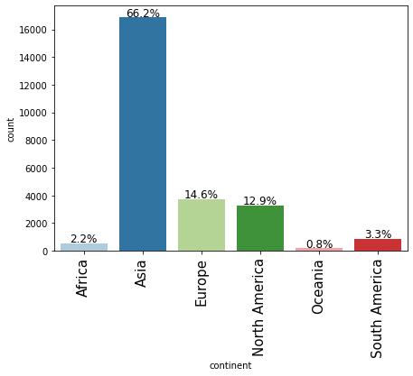

```python
count_percentage(df, "continent")
print("-" * 50)
print("\n")
labeled_barplot(df, "continent")
```

### Observations

- It is easy to see that Asia leads the continents in the most applicants
- Asia, Eurpoe, and North America consitiute 93.7% of the applicants

### Analysis of Education of Employee

```
education_of_employee with percentage of total

             education_of_employee  Percentage
Bachelor's                   10234    0.401648
Master's                      9634    0.378100
High School                   3420    0.134223
Doctorate                     2192    0.086028
--------------------------------------------------
```

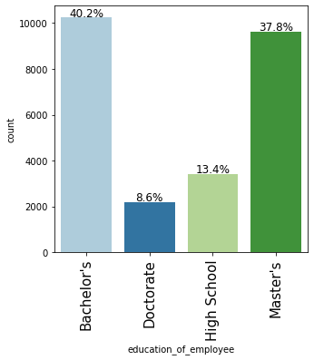

```python
count_percentage(df, "education_of_employee")
print("-" * 50)
print("\n")
labeled_barplot(df, "education_of_employee")
```

### Observations

- Bachelor's and Master's degrees are the dominant degrees for the applicants
- When combining all University level degrees, 86.6% of the applicants have some form of a higher education degree
  - This follows the idea that well educated people are in demand and will immigrate

### Analysis of Has Job Experience

```
has_job_experience with percentage of total

   has_job_experience  Percentage
Y               14802    0.580926
N               10678    0.419074
--------------------------------------------------
```

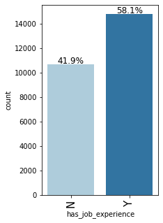

```python
count_percentage(df, "has_job_experience")
print("-" * 50)
print("\n")
labeled_barplot(df, "has_job_experience")
```

### Observations

- It is a roughly 60/40 split on if the applicant has job experience
- Given the education level, it would be safe to assume some of the applicants are recent graduates willing to move to another country to start their careers.
- The other applicants have experience in job's field, but are willing to immigrate

### Analysis of Requires Job Training

```
requires_job_training with percentage of total

   requires_job_training  Percentage
N                  22525    0.884027
Y                   2955    0.115973
--------------------------------------------------
```

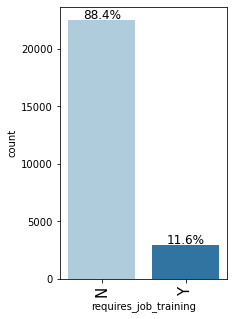

```python
count_percentage(df, "requires_job_training")
print("-" * 50)
print("\n")
labeled_barplot(df, "requires_job_training")
```

### Observations

- By "Job Training", we assume the applicant already has knowledge in the field of the job, but will need education on how the actual job works
- The vast majority of the applicants do not require job training
- Given the level of education and work experience, some of the applicants are new graduates with lots of knowledge, but not much experience

### Analysis of Number of Employees

```
no_of_employees with percentage of total

       no_of_employees  Percentage
183                 18    0.000706
854                 16    0.000628
724                 16    0.000628
766                 15    0.000589
1476                15    0.000589
...                ...         ...
5876                 1    0.000039
5536                 1    0.000039
47866                1    0.000039
4700                 1    0.000039
40224                1    0.000039

[7105 rows x 2 columns]
--------------------------------------------------
```

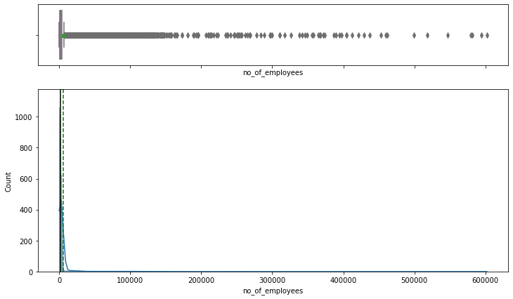

```python
count_percentage(df, "no_of_employees")
print("-" * 50)
print("\n")
histogram_boxplot(df, "no_of_employees")
```

```python
tempdf = pd.DataFrame(columns=["no_of_employees", "Percentage"])
tempdf["no_of_employees"] = df["no_of_employees"].value_counts()
tempdf["Percentage"] = df["no_of_employees"].value_counts(normalize=True)
tempdf.reset_index(drop=True, inplace=True)

print("\n\nFirst 20 entries number of employees:")
print(tempdf.head(20))

del tempdf
```

```
First 20 entries number of employees:
    no_of_employees  Percentage
0                18    0.000706
1                16    0.000628
2                16    0.000628
3                15    0.000589
4                15    0.000589
5                14    0.000549
6                14    0.000549
7                14    0.000549
8                14    0.000549
9                14    0.000549
10               13    0.000510
11               13    0.000510
12               13    0.000510
13               13    0.000510
14               13    0.000510
15               13    0.000510
16               13    0.000510
17               13    0.000510
18               13    0.000510
19               13    0.000510
```

### Observations

- From the Data Overview section we know the following about the number of employees:
  - Mean: 5667
  - Median: 2109
  - Minimun: -26 (Need to wonder about this)
  - Maximum: 602,069
- The data is heavily skewed right
- In terms of number of employees, the numbers are all over the place with a very large range
  - Probably would be best to group the number of employees into T-Shirt sizes: Small, Medium, Large, Extra Large

### Analysis of Year of Establishment

```
yr_of_estab with percentage of total

      yr_of_estab  Percentage
1998         1134    0.044505
2005         1051    0.041248
2001         1017    0.039914
2007          994    0.039011
1999          870    0.034144
...           ...         ...
1842            6    0.000235
1846            4    0.000157
1822            4    0.000157
1810            3    0.000118
1824            2    0.000078

[199 rows x 2 columns]
--------------------------------------------------
```

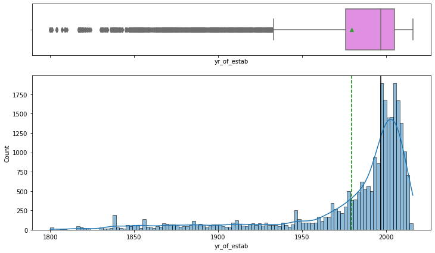

```python
count_percentage(df, "yr_of_estab")
print("-" * 50)
print("\n")
histogram_boxplot(df, "yr_of_estab")
```

### Observations

- Like number of employees, there is a great range to the year the business was started
- From the Data Overview section, we know the following about the year of establishment:
  - Mean: 1979
  - Median: 1997
  - Minimum: 1800
  - Maximum: 2016
- 50% of the companies where founded during the period: 1997 - 2016
- Data is definately left skewed
- Working with companies that are relativily new
  - This is assuming a 25 old company is "new"
    - However, a 25 year old company would be new to a company started before 1900

### Analysis of Region of Employment

```
region_of_employment with percentage of total

           region_of_employment  Percentage
Northeast                  7195    0.282378
South                      7017    0.275392
West                       6586    0.258477
Midwest                    4307    0.169035
Island                      375    0.014717
--------------------------------------------------
```

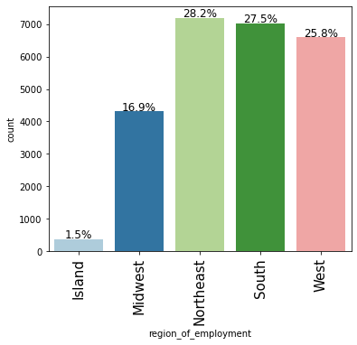

```python
count_percentage(df, "region_of_employment")
print("-" * 50)
print("\n")
labeled_barplot(df, "region_of_employment")
```

### Observations

- The majority of businesses are located in the Northeast, South, and West
  - Given the number of companies located in these areas, this is not a surprise
- Assuming "Island" means Hawaii, a number of 1.5% makes sense
- It would be interesting to see if the number for the Midwest could be improved

### Analysis of Prevailing Wage

```
prevailing_wage with percentage of total

             prevailing_wage  Percentage
82560.2800                 2    0.000078
122.6500                   2    0.000078
60948.1500                 2    0.000078
64357.5800                 2    0.000078
108.1200                   2    0.000078
...                      ...         ...
25713.9800                 1    0.000039
101656.6400                1    0.000039
65665.5500                 1    0.000039
50.8813                    1    0.000039
70876.9100                 1    0.000039

[25454 rows x 2 columns]
--------------------------------------------------
```

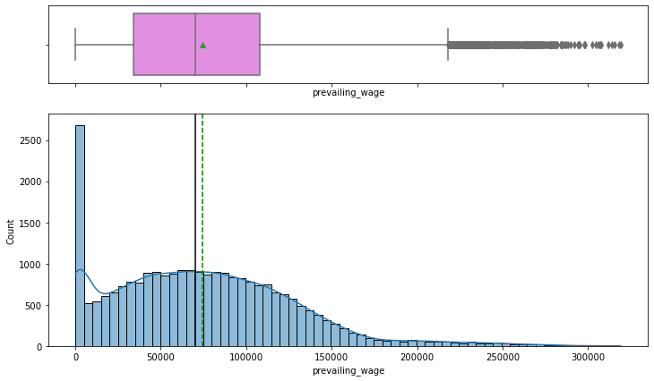

```python
count_percentage(df, "prevailing_wage")
print("-" * 50)
print("\n")
histogram_boxplot(df, "prevailing_wage")
```

### Observations

- Given that there are four wage types and such a big spread in the values, we are going to analyze each wage type separately

### Analysis of Hour Wage Type

```
The lowest prevailing hourlyly wage is 2.1367
The highest prevailing hourly wage is 999.9195
The mean prevailing hourly wage is 414.57
The median prevailing hourly wage is 372.6523


Prevailing wage for hourly wage type

prevailing_wage with percentage of total

          prevailing_wage  Percentage
138.7600                2    0.000927
134.1500                2    0.000927
105.9600                2    0.000927
108.1200                2    0.000927
118.4300                2    0.000927
...                   ...         ...
44.8222                 1    0.000464
124.7300                1    0.000464
786.1880                1    0.000464
318.4801                1    0.000464
516.4101                1    0.000464

[2145 rows x 2 columns]
--------------------------------------------------
```

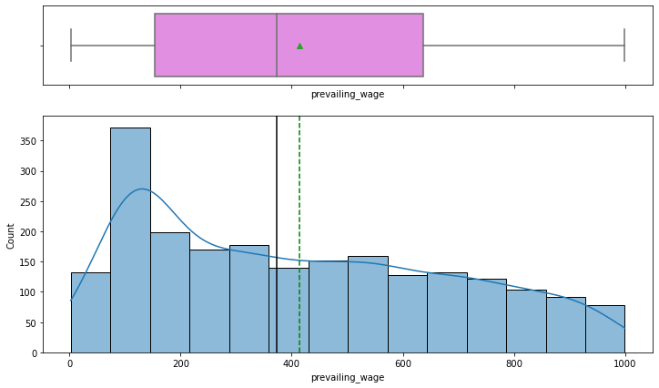

```python
tempdf = df[df["unit_of_wage"] == "Hour"]

print("The lowest prevailing hourlyly wage is", tempdf["prevailing_wage"].min())
print("The highest prevailing hourly wage is", tempdf["prevailing_wage"].max())
print("The mean prevailing hourly wage is", round(tempdf["prevailing_wage"].mean(), 2))
print("The median prevailing hourly wage is", tempdf["prevailing_wage"].median())
print("\n")

print("Prevailing wage for hourly wage type\n")
count_percentage(tempdf, "prevailing_wage")
print("-" * 50)
print("\n")
histogram_boxplot(tempdf, "prevailing_wage")

del tempdf
```

### Observations

- There is a large variance of wages going from 2.14 to 999.92
- No outliers in the data for hourly wage
- The mean and median values are somewhat close
- The median was probably pulled lower by the wages approximately between 66 - 132
  - Second bar on the left and estimating the bars to roughly include 66 wages
- The second majority of wages are of the hourly type

### Analysis of Week Wage Type

```
The lowest prevailing weekly wage is 2183.23
The highest prevailing weekly wage is 280175.95
The mean prevailing weekly wage is 85606.82
The median prevailing weekly wage is 85075.82


Prevailing wage for weekly wage type

prevailing_wage with percentage of total

           prevailing_wage  Percentage
98966.72                 1    0.003676
108734.42                1    0.003676
84729.79                 1    0.003676
94005.34                 1    0.003676
93972.30                 1    0.003676
...                    ...         ...
95478.53                 1    0.003676
34091.08                 1    0.003676
29465.04                 1    0.003676
144234.86                1    0.003676
154057.64                1    0.003676

[272 rows x 2 columns]
--------------------------------------------------
```

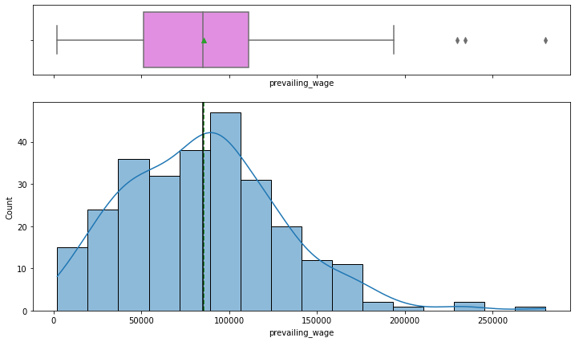

```python
tempdf = df[df["unit_of_wage"] == "Week"]

print("The lowest prevailing weekly wage is", tempdf["prevailing_wage"].min())
print("The highest prevailing weekly wage is", tempdf["prevailing_wage"].max())
print("The mean prevailing weekly wage is", round(tempdf["prevailing_wage"].mean(), 2))
print("The median prevailing weekly wage is", tempdf["prevailing_wage"].median())
print("\n")

print("Prevailing wage for weekly wage type\n")
count_percentage(tempdf, "prevailing_wage")
print("-" * 50)
print("\n")
histogram_boxplot(tempdf, "prevailing_wage")

del tempdf
```

### Analysis of Month Wage Type

```
The lowest prevailing monthly wage is 1599.28
The highest prevailing monthly wage is 264362.95
The mean prevailing monthly wage is 87592.86
The median prevailing monthly wage is 81826.01


Prevailing wage for monthly wage type

prevailing_wage with percentage of total

           prevailing_wage  Percentage
141796.39                1    0.011236
3078.37                  1    0.011236
21104.66                 1    0.011236
144778.25                1    0.011236
60248.65                 1    0.011236
23656.43                 1    0.011236
72476.76                 1    0.011236
246099.93                1    0.011236
157009.87                1    0.011236
44659.23                 1    0.011236
19425.40                 1    0.011236
11722.23                 1    0.011236
65697.01                 1    0.011236
22950.92                 1    0.011236
53314.50                 1    0.011236
212271.15                1    0.011236
26560.26                 1    0.011236
123845.84                1    0.011236
140501.71                1    0.011236
97554.99                 1    0.011236
135780.32                1    0.011236
32718.74                 1    0.011236
54573.93                 1    0.011236
3048.50                  1    0.011236
115971.85                1    0.011236
94376.07                 1    0.011236
1599.28                  1    0.011236
81826.01                 1    0.011236
78587.67                 1    0.011236
```

[output cut: 46 more lines]

```
58784.81                 1    0.011236
111559.85                1    0.011236
35475.13                 1    0.011236
69869.40                 1    0.011236
67930.73                 1    0.011236
264362.95                1    0.011236
142696.27                1    0.011236
121838.73                1    0.011236
50268.99                 1    0.011236
75288.35                 1    0.011236
118191.51                1    0.011236
42335.11                 1    0.011236
28813.97                 1    0.011236
86778.04                 1    0.011236
--------------------------------------------------
```

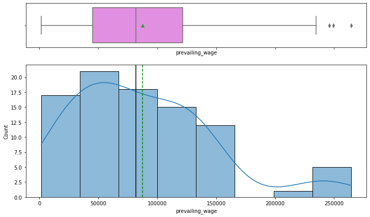

```python
tempdf = df[df["unit_of_wage"] == "Month"]

print("The lowest prevailing monthly wage is", tempdf["prevailing_wage"].min())
print("The highest prevailing monthly wage is", tempdf["prevailing_wage"].max())
print("The mean prevailing monthly wage is", round(tempdf["prevailing_wage"].mean(), 2))
print("The median prevailing monthly wage is", tempdf["prevailing_wage"].median())
print("\n")

print("Prevailing wage for monthly wage type\n")
count_percentage(tempdf, "prevailing_wage")
print("-" * 50)
print("\n")
histogram_boxplot(tempdf, "prevailing_wage")

del tempdf
```

### Observations

- Like with the other wage types, there is a large variance between the minimum and maximum monthly wages
- Montly wage has the fewest number of wages in the set
- The highest three monthly wages are outliers
- The rest of the monthly wages are close to being uniformly distributed
- The mean and median are also close, but as not as close as for the weekly wage type

### Analysis of Year Wage Type

```
The lowest prevailing yearly wage is 100.0
The highest prevailing yearly wage is 319210.27
The mean prevailing yearly wage is 81228.08
The median prevailing yearly wage is 76174.5


Prevailing wage for yearly wage type

prevailing_wage with percentage of total

           prevailing_wage  Percentage
6036.67                  2    0.000087
93356.03                 2    0.000087
82560.28                 2    0.000087
74645.92                 2    0.000087
60948.15                 2    0.000087
...                    ...         ...
46100.72                 1    0.000044
104941.46                1    0.000044
188121.77                1    0.000044
108544.37                1    0.000044
70876.91                 1    0.000044

[22950 rows x 2 columns]
--------------------------------------------------
```

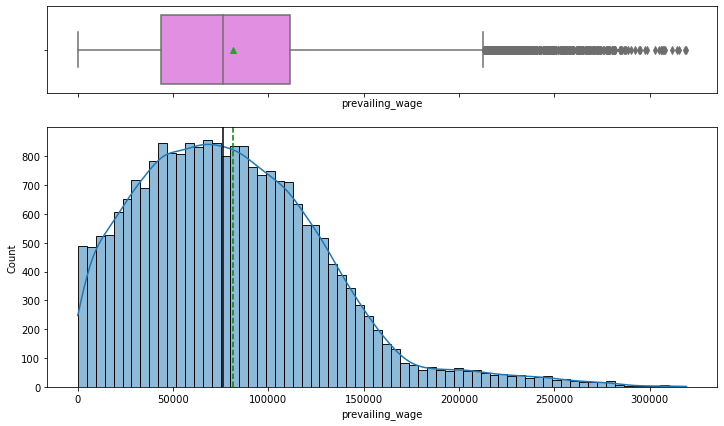

```python
tempdf = df[df["unit_of_wage"] == "Year"]

print("The lowest prevailing yearly wage is", tempdf["prevailing_wage"].min())
print("The highest prevailing yearly wage is", tempdf["prevailing_wage"].max())
print("The mean prevailing yearly wage is", round(tempdf["prevailing_wage"].mean(), 2))
print("The median prevailing yearly wage is", tempdf["prevailing_wage"].median())
print("\n")

print("Prevailing wage for yearly wage type\n")
count_percentage(tempdf, "prevailing_wage")
print("-" * 50)
print("\n")
histogram_boxplot(tempdf, "prevailing_wage")

del tempdf
```

### Observations

- Like with the other wage types, there is a large variance between the lowest and highest yearly wage
- The mean and median are close to each other and probably second to the weekly wage amounts
- There are many outliers giving the histogram a long right tail
- Subtracting or ignoring the right tail, the yearly wages are close to being normally distributed
- Assuming the wages over 200,000 are for executives and other high ranking managers

### Analysis of Unit of Wage

```
unit_of_wage with percentage of total

       unit_of_wage  Percentage
Year          22962    0.901177
Hour           2157    0.084655
Week            272    0.010675
Month            89    0.003493
--------------------------------------------------
```

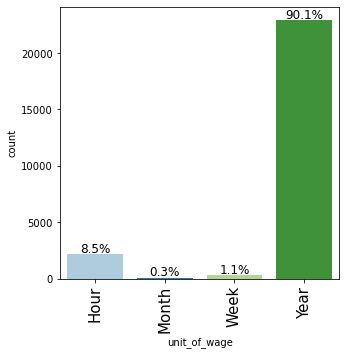

```python
count_percentage(df, "unit_of_wage")
print("-" * 50)
print("\n")
labeled_barplot(df, "unit_of_wage")
```

### Observations

- The vast majority of the jobs have a unit of wage of a year
- Second highest unit of wage is hourly
- Given this, it can be assumed most of the applicants are not labour or contractors
- Given level of education, it can be assumed the applicants are "white collar workers" employed in some type of office/remote environment

### Analysis of Full Time Position

```
full_time_position with percentage of total

   full_time_position  Percentage
Y               22773     0.89376
N                2707     0.10624
--------------------------------------------------
```

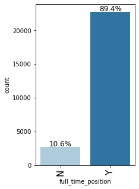

```python
count_percentage(df, "full_time_position")
print("-" * 50)
print("\n")
labeled_barplot(df, "full_time_position")
```

### Observations

- The vast majorioty of position are full time positions which is not surprising since the applicant is changing countries
- It would be a big bet to change countries for a part time position
- Given this and full time positions and level of education and yearly salary, it can be assumed the applicants are "white collar workers" employed in some type of office/remote environment

### Analysis of Case Status

```
case_status with percentage of total

           case_status  Percentage
Certified        17018    0.667896
Denied            8462    0.332104
--------------------------------------------------
```

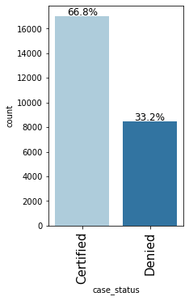

```python
count_percentage(df, "case_status")
print("-" * 50)
print("\n")
labeled_barplot(df, "case_status")
```

### Observations

- There is a roughly two-thirds split between "Certified" and "Denied"
- This data needs to be combined with the other data points like level of education to determine why there is a two-thirds split
- Otherwise, there is not much that can be done with this data point

## Bivariate Analysis

### Analysis of Correlation

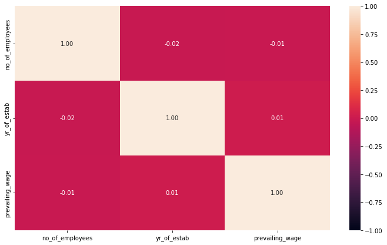

```
Wall time: 378 ms
```

```python
%%time

cols_list = df.select_dtypes(include=np.number).columns.tolist()

plt.figure(figsize=(12, 7))
sns.heatmap(df[cols_list].corr(), annot=True, vmin=-1, vmax=1, fmt=".2f")
plt.show()
```

### Observations

- There is no correlation between the numbers as they are all independent of each other
  - Year of establishment does not relate to anything
- There could be a correlation between number of employees and prevailing wage as larger companies might be able to pay better
  - However, this is always the case -- see all the start ups in Silicon Valley
- It would be interesting to see the correlation between number of employees and prevailing wage and geographic location

### Analysis of Education and Visa Certification

```
Totals
case_status            Certified  Denied    All
education_of_employee
All                        17018    8462  25480
Bachelor's                  6367    3867  10234
High School                 1164    2256   3420
Master's                    7575    2059   9634
Doctorate                   1912     280   2192


Percentages
case_status            Certified    Denied
education_of_employee
High School             0.340351  0.659649
Bachelor's              0.622142  0.377858
All                     0.667896  0.332104
Master's                0.786278  0.213722
Doctorate               0.872263  0.127737
------------------------------------------------------------------------------------------------------------------------
```

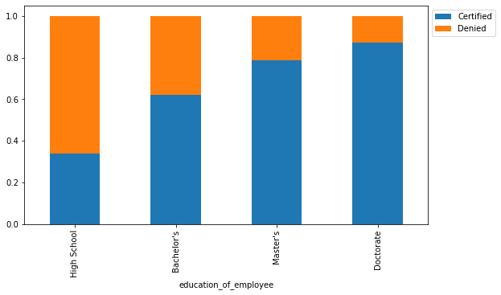

```
Totals
case_status            Certified  Denied    All
education_of_employee
All                        17018    8462  25480
Bachelor's                  6367    3867  10234
High School                 1164    2256   3420
Master's                    7575    2059   9634
Doctorate                   1912     280   2192


Percentages
case_status            Certified    Denied
education_of_employee
High School             0.340351  0.659649
Bachelor's              0.622142  0.377858
All                     0.667896  0.332104
Master's                0.786278  0.213722
Doctorate               0.872263  0.127737
------------------------------------------------------------------------------------------------------------------------
```

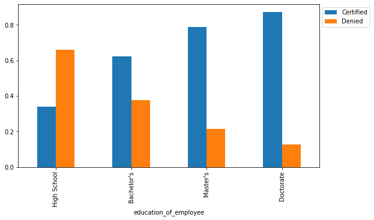

```python
stacked_barplot(df, "education_of_employee", "case_status")
print("\n")
side_barplot(df, "education_of_employee", "case_status")
```

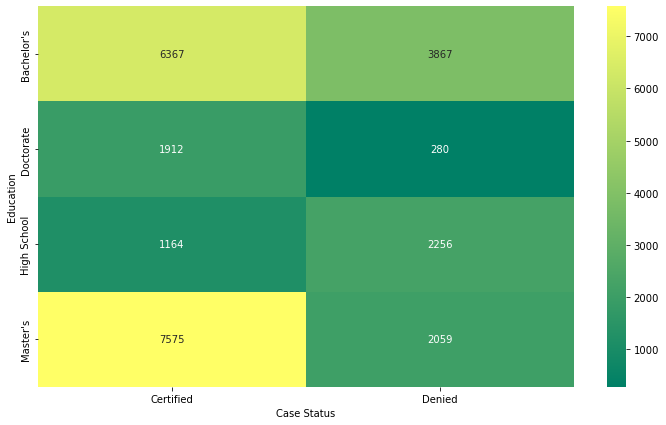

```python
plt.figure(figsize=(12, 7))
sns.heatmap(
    pd.crosstab(df["education_of_employee"], df["case_status"]),
    annot=True,
    fmt="g",
    cmap="summer",
)

plt.ylabel("Education")
plt.xlabel("Case Status")
plt.show()
```

### Observations

- As mentioned in the historial overview section, the applicants with the highest education are the likely to want to immigate and to have the best chance of doing it
- Doctorate holders are the smallest group, but they have the highest rate of acceptance
- Master's holders have a high acceptance rate also
- Bachelor's holders have a roughly two-thirds acceptance rate while this is not great, it is still pretty good
- The lowest acceptance rate is for people with only a High School level of eduction
- It pays to be well educated

### Analysis of Education and Visa Certification by Each Region

Do the analysis of education and visa certification by each region to determine if there is any pattern or patters to which level of eduction is certified the most.

```
Analysis for continent: Asia
Totals
case_status            Certified  Denied    All
education_of_employee
All                        11012    5849  16861
Bachelor's                  4407    2761   7168
High School                  676    1614   2290
Master's                    5149    1331   6480
Doctorate                    780     143    923


Percentages
case_status            Certified    Denied
education_of_employee
High School             0.295197  0.704803
Bachelor's              0.614816  0.385184
All                     0.653105  0.346895
Master's                0.794599  0.205401
Doctorate               0.845070  0.154930
------------------------------------------------------------------------------------------------------------------------
```

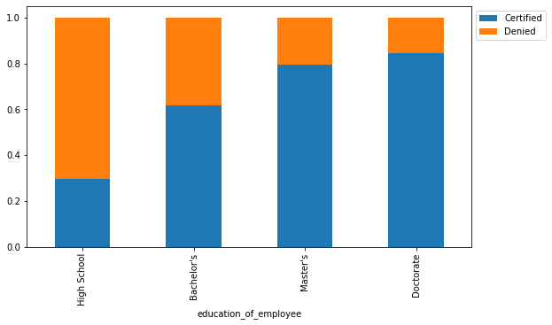

```
Totals
case_status            Certified  Denied    All
education_of_employee
All                        11012    5849  16861
Bachelor's                  4407    2761   7168
High School                  676    1614   2290
Master's                    5149    1331   6480
Doctorate                    780     143    923


Percentages
case_status            Certified    Denied
education_of_employee
High School             0.295197  0.704803
Bachelor's              0.614816  0.385184
All                     0.653105  0.346895
Master's                0.794599  0.205401
Doctorate               0.845070  0.154930
------------------------------------------------------------------------------------------------------------------------
```

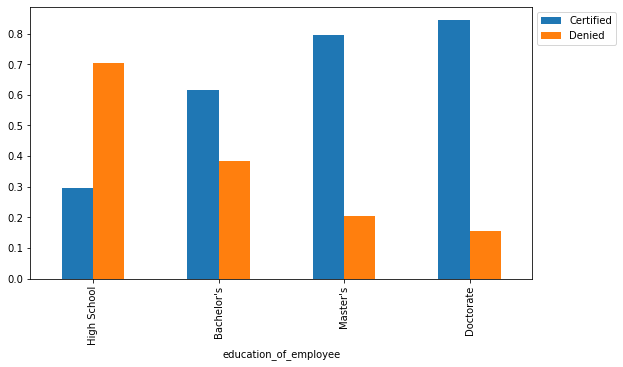

```
,

Analysis for continent: Africa
Totals
case_status            Certified  Denied  All
education_of_employee
All                          397     154  551
Bachelor's                    81      62  143
High School                   23      43   66
Master's                     250      38  288
Doctorate                     43      11   54


Percentages
case_status            Certified    Denied
education_of_employee
High School             0.348485  0.651515
Bachelor's              0.566434  0.433566
All                     0.720508  0.279492
Doctorate               0.796296  0.203704
Master's                0.868056  0.131944
------------------------------------------------------------------------------------------------------------------------
```

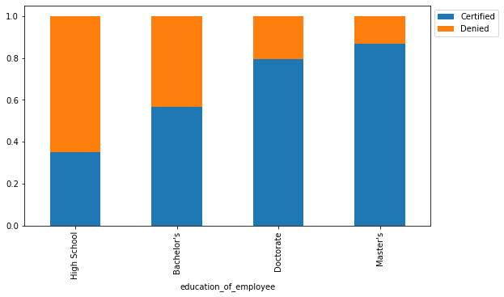

```
Totals
case_status            Certified  Denied  All
education_of_employee
All                          397     154  551
Bachelor's                    81      62  143
High School                   23      43   66
Master's                     250      38  288
Doctorate                     43      11   54


Percentages
case_status            Certified    Denied
education_of_employee
High School             0.348485  0.651515
Bachelor's              0.566434  0.433566
All                     0.720508  0.279492
Doctorate               0.796296  0.203704
Master's                0.868056  0.131944
------------------------------------------------------------------------------------------------------------------------
```

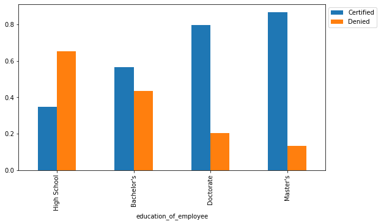

```
,

Analysis for continent: North America
Totals
case_status            Certified  Denied   All
education_of_employee
All                         2037    1255  3292
Bachelor's                   641     584  1225
Master's                     979     429  1408
High School                  210     191   401
Doctorate                    207      51   258


Percentages
case_status            Certified    Denied
education_of_employee
Bachelor's              0.523265  0.476735
High School             0.523691  0.476309
All                     0.618773  0.381227
Master's                0.695312  0.304688
Doctorate               0.802326  0.197674
------------------------------------------------------------------------------------------------------------------------
```

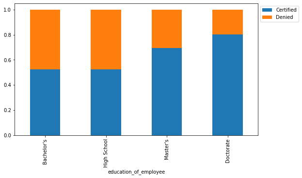

```
Totals
case_status            Certified  Denied   All
education_of_employee
All                         2037    1255  3292
Bachelor's                   641     584  1225
Master's                     979     429  1408
High School                  210     191   401
Doctorate                    207      51   258


Percentages
case_status            Certified    Denied
education_of_employee
Bachelor's              0.523265  0.476735
High School             0.523691  0.476309
All                     0.618773  0.381227
Master's                0.695312  0.304688
Doctorate               0.802326  0.197674
------------------------------------------------------------------------------------------------------------------------
```

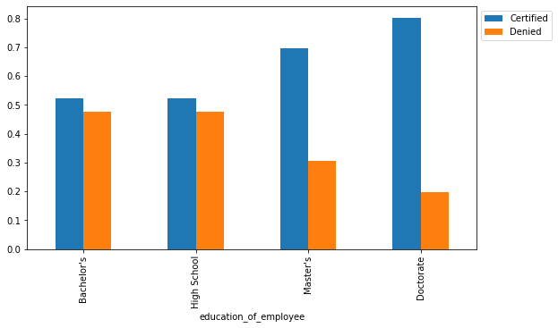

```
,

Analysis for continent: Europe
Totals
case_status            Certified  Denied   All
education_of_employee
All                         2957     775  3732
High School                  162     328   490
Bachelor's                  1040     259  1299
Master's                     967     130  1097
Doctorate                    788      58   846


Percentages
case_status            Certified    Denied
education_of_employee
High School             0.330612  0.669388
All                     0.792337  0.207663
Bachelor's              0.800616  0.199384
Master's                0.881495  0.118505
Doctorate               0.931442  0.068558
------------------------------------------------------------------------------------------------------------------------
```

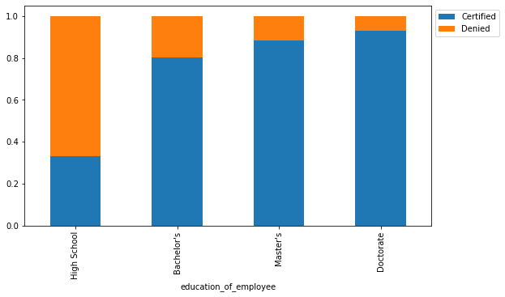

```
Totals
case_status            Certified  Denied   All
education_of_employee
All                         2957     775  3732
High School                  162     328   490
Bachelor's                  1040     259  1299
Master's                     967     130  1097
Doctorate                    788      58   846


Percentages
case_status            Certified    Denied
education_of_employee
High School             0.330612  0.669388
All                     0.792337  0.207663
Bachelor's              0.800616  0.199384
Master's                0.881495  0.118505
Doctorate               0.931442  0.068558
------------------------------------------------------------------------------------------------------------------------
```

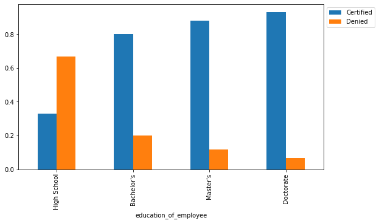

```
,

Analysis for continent: South America
Totals
case_status            Certified  Denied  All
education_of_employee
All                          493     359  852
Bachelor's                   160     173  333
Master's                     184     109  293
High School                   74      63  137
Doctorate                     75      14   89


Percentages
case_status            Certified    Denied
education_of_employee
Bachelor's              0.480480  0.519520
High School             0.540146  0.459854
All                     0.578638  0.421362
Master's                0.627986  0.372014
Doctorate               0.842697  0.157303
------------------------------------------------------------------------------------------------------------------------
```

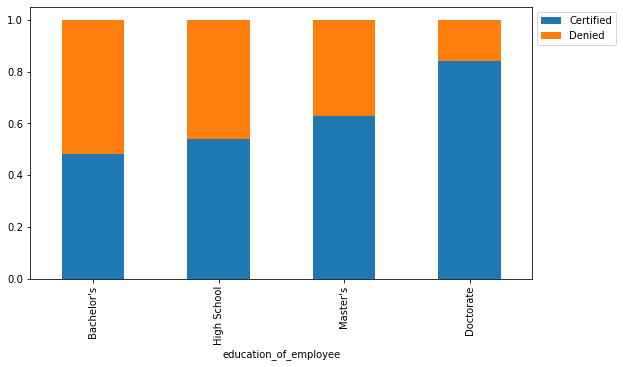

```
Totals
case_status            Certified  Denied  All
education_of_employee
All                          493     359  852
Bachelor's                   160     173  333
Master's                     184     109  293
High School                   74      63  137
Doctorate                     75      14   89


Percentages
case_status            Certified    Denied
education_of_employee
Bachelor's              0.480480  0.519520
High School             0.540146  0.459854
All                     0.578638  0.421362
Master's                0.627986  0.372014
Doctorate               0.842697  0.157303
------------------------------------------------------------------------------------------------------------------------
```

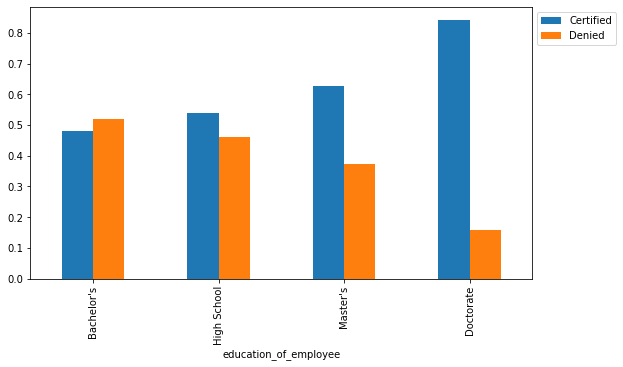

```
,

Analysis for continent: Oceania
Totals
case_status            Certified  Denied  All
education_of_employee
All                          122      70  192
Bachelor's                    38      28   66
Master's                      46      22   68
High School                   19      17   36
Doctorate                     19       3   22


Percentages
case_status            Certified    Denied
education_of_employee
High School             0.527778  0.472222
Bachelor's              0.575758  0.424242
All                     0.635417  0.364583
Master's                0.676471  0.323529
Doctorate               0.863636  0.136364
------------------------------------------------------------------------------------------------------------------------
```

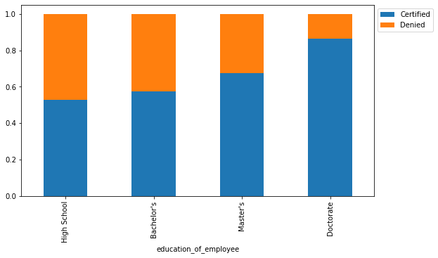

```
Totals
case_status            Certified  Denied  All
education_of_employee
All                          122      70  192
Bachelor's                    38      28   66
Master's                      46      22   68
High School                   19      17   36
Doctorate                     19       3   22


Percentages
case_status            Certified    Denied
education_of_employee
High School             0.527778  0.472222
Bachelor's              0.575758  0.424242
All                     0.635417  0.364583
Master's                0.676471  0.323529
Doctorate               0.863636  0.136364
------------------------------------------------------------------------------------------------------------------------
```

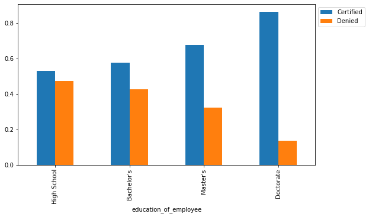

```
,

Wall time: 1.84 s
```

```python
%%time

cont = df["continent"].unique().tolist()
for x in cont:
    temp2df = df[df["continent"] == x]
    print("Analysis for continent:", x)
    stacked_barplot(temp2df, "education_of_employee", "case_status")
    print("\n")
    side_barplot(temp2df, "education_of_employee", "case_status")
    print("\n,\n")

del temp2df  # free memory
```